# **Example of Vector Autoregressive Models (VAR)**

We will use the number of passengers and the number of flights. Our aim is to understand the dynamic relationship between these two variables over time.

```python
from google.colab import files
uploaded = files.upload()
```

Upload widget is only available when the cell has been executed in the current browser session. Please rerun this cell to enable.

```
Saving air traffic.xlsx to air traffic (1).xlsx
```

```python
!pip install pmdarima
```

```python
import pandas as pd
import numpy as np
df = pd.read_excel('air traffic.xlsx')
from statsmodels.tsa.seasonal import seasonal_decompose
from statsmodels.tsa.holtwinters import ExponentialSmoothing
import matplotlib.pyplot as plt
import seaborn as sns
from keras.models import Sequential
from keras.layers import LSTM, Dense
from sklearn.preprocessing import MinMaxScaler
from sklearn.metrics import mean_squared_error
import matplotlib.pyplot as plt
import statsmodels.api as sm
from scipy.signal import periodogram
from sklearn.metrics import mean_absolute_error
from statsmodels.tsa.stattools import adfuller
from statsmodels.tsa.seasonal import seasonal_decompose
from statsmodels.graphics.tsaplots import plot_acf, plot_pacf
from statsmodels.tsa.arima.model import ARIMA
from pmdarima.arima import auto_arima
from statsmodels.tsa.statespace.sarimax import SARIMAX
from statsmodels.tsa.api import VAR
```

```python
# Convert object-type columns to numeric format
for col in df.columns:
    if df[col].dtype == 'object':
        df[col] = pd.to_numeric(df[col].str.replace(',', ''), errors='coerce')

# Combine 'Year' and 'Month' columns to create a new 'Date' column
df['Date'] = pd.to_datetime(df[['Year', 'Month']].astype(str).agg('-'.join, axis=1))

# Set the 'Date' column as the index
df.set_index("Date", inplace=True)

# Set the frequency of the index
df.index.freq = 'MS'  # 'MS' stands for Month Start

# Optionally, you can drop the 'Year' and 'Month' columns if they are no longer needed
df.drop(columns=['Year', 'Month'], inplace=True)

# Calculate the index to split the data (80% for training, 20% for testing)
split_index = int(len(df) * 0.80)

# Split the data into training (80%) and testing (20%) sets
train_data = df.iloc[:split_index]
test_data = df.iloc[split_index:]

# Display the shapes of the training and testing sets
print("Training data shape:", train_data.shape)
print("Testing data shape:", test_data.shape)
```

```
Training data shape: (163, 15)
Testing data shape: (41, 15)
```

## Stationary

Before implementing the VAR we need to check also for stationarity in the other series, that is, the number of passengers series.

In the number of flights we have done it already in the project implementing a seasonal difference to make it stationary

```python
  # Taking the natural logarithm of the 'Flt' column in train_data
train_data['Flt'] = np.log(train_data['Flt'])

# Taking the natural logarithm of the 'Flt' column in test_data
test_data['Flt'] = np.log(test_data['Flt'])
```

[figure not shown]

```python
# Difference the resulting series again with a lag of 12
flt_diffa12 = np.diff(train_data['Flt'], 12)

# Plot the differenced series
plt.plot(flt_diffa12)
plt.xlabel('Year')
plt.ylabel('Number of Flights')
plt.title('Seasonal Differenced Flights Time Series')
plt.show()
```

```python
result4 = adfuller(flt_diffa12)
print('ADF Statistic: %f' % result4[0])
print('p-value: %f' % result4[1])
print('Critical Values:')
for key, value in result4[4].items():
  print('\t%s: %.3f' % (key, value))
```

```
ADF Statistic: -16.451014
p-value: 0.000000
Critical Values:
	1%: -3.479
	5%: -2.883
	10%: -2.578
```

Now we have to check the number of passengers series

```python
# Taking the natural logarithm of the 'Pax' column in train_data
train_data['Pax'] = np.log(train_data['Pax'])

# Taking the natural logarithm of the 'Pax' column in test_data
test_data['Pax'] = np.log(test_data['Pax'])
```

```python
result = adfuller(train_data['Pax'])
print('ADF Statistic: %f' % result[0])
print('p-value: %f' % result[1])
print('Critical Values:')
for key, value in result[4].items():
  print('\t%s: %.3f' % (key, value))
```

```
ADF Statistic: -1.978869
p-value: 0.295914
Critical Values:
	1%: -3.475
	5%: -2.881
	10%: -2.577
```

As we can observed, the series aren't stationary, so we applied the first regular difference of both series. However, this difference didn't make the series being stationary so we applied the first seasonal difference instead.

[figure not shown]

```python
# Difference the resulting series again with a lag of 12
pax_diffa12 = np.diff(train_data['Pax'], 12)

# Plot the differenced series
plt.plot(pax_diffa12)
plt.xlabel('Year')
plt.ylabel('Number of Flights')
plt.title('Seasonal Differenced Flights Time Series')
plt.show()
```

```python
result4 = adfuller(pax_diffa12)
print('ADF Statistic: %f' % result4[0])
print('p-value: %f' % result4[1])
print('Critical Values:')
for key, value in result4[4].items():
  print('\t%s: %.3f' % (key, value))
```

```
ADF Statistic: -18.501230
p-value: 0.000000
Critical Values:
	1%: -3.479
	5%: -2.883
	10%: -2.578
```

Now the series is stationary after applying a seasonal difference, hence we have both series stationary and can start modelling

## Modelling

Before perform the VAR model, we needed to create a new dataframe with both series.

```python
# Convert the differenced series into a DataFrame
df_diff = pd.DataFrame({'Flt_diffa12': flt_diffa12, 'Pax_diffa12': pax_diffa12})

# Drop missing values if any
df_diff.dropna(inplace=True)
```

The next step was to find the right VAR(p) order, based on the AIC and BIC criterion. We created a loop to find this AIC and BIC of each p-order.

```python
# Estimate the VAR model
# Selecting the order (p) of the VAR model
model = VAR(df_diff)
for i in range(1, 10):
    result = model.fit(i)
    print('Order =', i)
    print('AIC : ', result.aic)
    print('BIC : ', result.bic)
```

```
Order = 1
AIC :  10.810851317063694
BIC :  10.931276728827545
Order = 2
AIC :  6.933231420151104
BIC :  7.134838554778316
Order = 3
AIC :  5.597486827436444
BIC :  5.881006907387103
Order = 4
AIC :  4.326413000489932
BIC :  4.692588419279165
Order = 5
AIC :  2.8019124426645097
BIC :  3.2514970021000127
Order = 6
AIC :  1.5930264955644537
BIC :  2.126785649377798
Order = 7
AIC :  -0.5740922897823434
BIC :  0.04461881429599024
Order = 8
AIC :  -2.570267024738046
BIC :  -1.8658144553056204
Order = 9
AIC :  -3.3647034045094397
BIC :  -2.573707431348539
```

The VAR(p) with the lowest AIC and BIC is the one with order 9, so we implemented the VAR model with this order.

```python
# Estimate the VAR model
# Selecting the order (p) of the VAR model
var_model = VAR(df_diff)
selected_order = 9  # selected order is 9 based on lowest AIC/BIC

# Fitting the model with the selected order
model_fitted = var_model.fit(selected_order)
print(model_fitted.summary())
```

```
  Summary of Regression Results
==================================
Model:                         VAR
Method:                        OLS
Date:           Wed, 20, Mar, 2024
Time:                     18:31:09
--------------------------------------------------------------------
No. of Equations:         2.00000    BIC:                   -2.57371
Nobs:                     142.000    HQIC:                  -3.04327
Log likelihood:          -126.085    FPE:                  0.0346841
AIC:                     -3.36470    Det(Omega_mle):       0.0269808
--------------------------------------------------------------------
Results for equation Flt_diffa12
=================================================================================
                    coefficient       std. error           t-stat            prob
---------------------------------------------------------------------------------
const                  0.002872         0.035310            0.081           0.935
L1.Flt_diffa12        -5.075640         0.110592          -45.895           0.000
L1.Pax_diffa12        -0.011352         0.077909           -0.146           0.884
L2.Flt_diffa12       -13.086251         0.515046          -25.408           0.000
L2.Pax_diffa12        -0.030914         0.358935           -0.086           0.931
L3.Flt_diffa12       -22.443317         1.221114          -18.379           0.000
L3.Pax_diffa12        -0.044822         0.841250           -0.053           0.958
L4.Flt_diffa12       -28.178453         1.935048          -14.562           0.000
L4.Pax_diffa12        -0.096535         1.322000           -0.073           0.942
L5.Flt_diffa12       -26.821861         2.233284          -12.010           0.000
L5.Pax_diffa12        -0.178595         1.520572           -0.117           0.907
L6.Flt_diffa12       -19.297145         1.920295          -10.049           0.000
L6.Pax_diffa12        -0.222931         1.307276           -0.171           0.865
L7.Flt_diffa12       -10.068233         1.206315           -8.346           0.000
L7.Pax_diffa12        -0.162034         0.823508           -0.197           0.844
L8.Flt_diffa12        -3.440482         0.507963           -6.773           0.000
L8.Pax_diffa12        -0.041040         0.348601           -0.118           0.906
L9.Flt_diffa12        -0.591975         0.109139           -5.424           0.000
L9.Pax_diffa12         0.010182         0.075252            0.135           0.892
=================================================================================

Results for equation Pax_diffa12
=================================================================================
                    coefficient       std. error           t-stat            prob
```

[output cut: 11 more lines]

```
L5.Pax_diffa12       -25.654936         2.219877          -11.557           0.000
L6.Flt_diffa12         0.047423         2.803432            0.017           0.987
L6.Pax_diffa12       -18.599647         1.908487           -9.746           0.000
L7.Flt_diffa12         0.317196         1.761095            0.180           0.857
L7.Pax_diffa12        -9.828493         1.202236           -8.175           0.000
L8.Flt_diffa12         0.256700         0.741574            0.346           0.729
L8.Pax_diffa12        -3.378480         0.508921           -6.639           0.000
L9.Flt_diffa12         0.068420         0.159332            0.429           0.668
L9.Pax_diffa12        -0.561721         0.109860           -5.113           0.000
=================================================================================

Correlation matrix of residuals
               Flt_diffa12  Pax_diffa12
Flt_diffa12       1.000000     0.771658
Pax_diffa12       0.771658     1.000000
```

**Results for each equation:**

For each equation, the coefficients, standard errors, t-statistics, and probabilities are presented for each lag term. Each coefficient represents the effect of the corresponding lagged variable on the current variable.

The probability (prob) column represents the p-value associated with each coefficient. Lower values indicate greater significance. For example, in the equation for Flt_diffa12, the coefficient of L1.Flt_diffa12 is -5.075640 with a very low p-value (prob=0.000), indicating that the lagged value of Flt_diffa12 has a significant impact on the current value of Flt_diffa12.

**Correlation matrix of residuals:**

This matrix shows the correlation between the residuals of Flt_diffa12 and Pax_diffa12. A high correlation suggests that there may be some unexplained relationship between the two variables not captured by the model. Here, the correlation coefficient is 0.771658, which means that the two series are strong correlated between the residuals of the two equations.

## Impulse Response Analysis

In a VAR model, impulse response analysis examines the dynamic response of each variable in the system to a one-time shock in one of the variables, while holding all other variables constant.

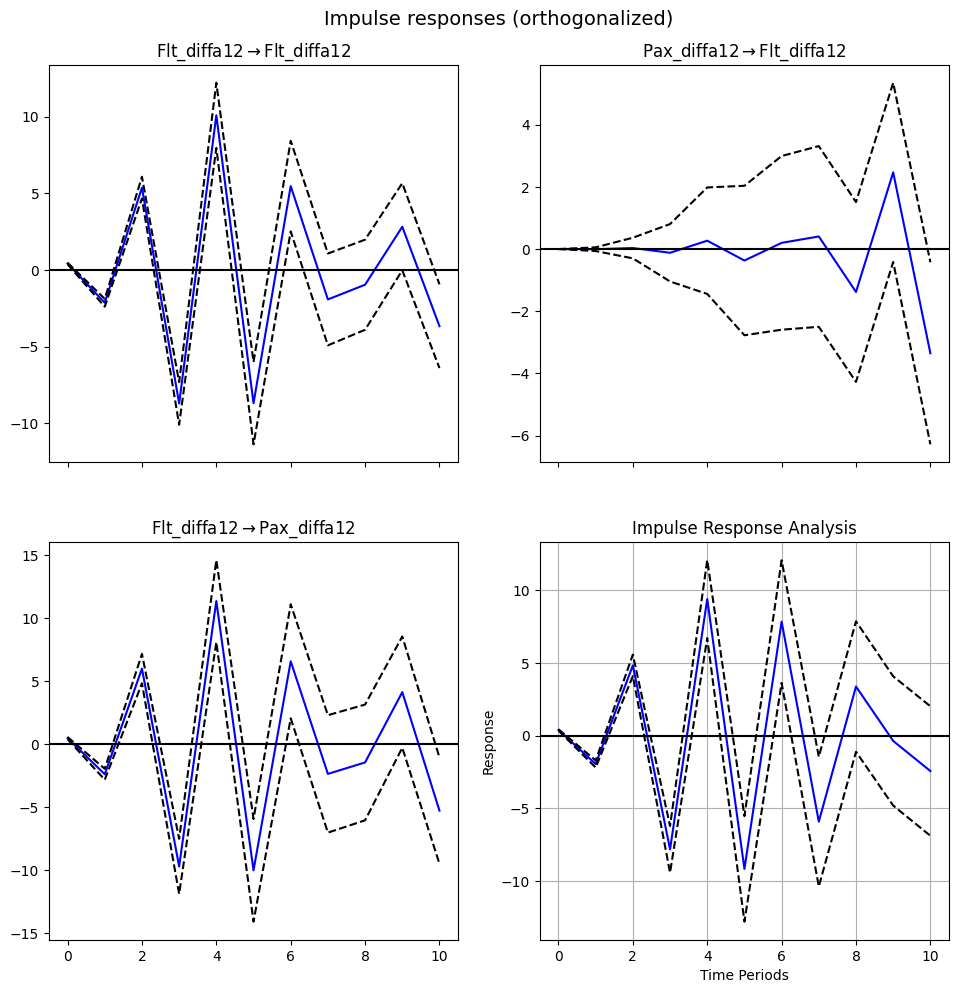

```python
# Perform Impulse Response Analysis
impulse_response = model_fitted.irf(10)  # Compute impulse responses for 10 periods

# Plot the Impulse Response Functions
impulse_response.plot(orth=True)  # Plot orthogonalized impulse response functions
plt.xlabel('Time Periods')  # Set label for the x-axis
plt.ylabel('Response')  # Set label for the y-axis
plt.title('Impulse Response Analysis')  # Set title for the plot
plt.grid(True)  # Add grid lines to the plot
plt.show()  # Display the plot
```

## Forecast error variance decomposition (FEVD)

Is a part of structural analysis which "decomposes" the variance of the forecast error into the contributions from specific exogenous shocks.

Intuitively this is useful because it demonstrates how important a shock is in explaining the variations of the variables in the model. Additionally, shows how that importance changes over time. For example, some shocks may not be responsible for variations in the short-run but may cause longer-term fluctuations.

```python
# FEVD
fevd = model_fitted.fevd(5)
fevd.summary()
```

```
FEVD for Flt_diffa12
     Flt_diffa12  Pax_diffa12
0       1.000000     0.000000
1       0.999996     0.000004
2       0.999968     0.000032
3       0.999860     0.000140
4       0.999586     0.000414

FEVD for Pax_diffa12
     Flt_diffa12  Pax_diffa12
0       0.595457     0.404543
1       0.599842     0.400158
2       0.603864     0.396136
3       0.604846     0.395154
4       0.598786     0.401214
```

- At period 0, Flt_diffa12 explains 100% of the forecast error variance, while Pax_diffa12 explains 0%. This suggests that, initially, all the forecast error variance in Flt_diffa12 is due to its own shocks, with no contribution from Pax_diffa12.
- At period 1, Flt_diffa12 still explains nearly all (99.9996%) of the forecast error variance, with a very minor contribution (0.0004%) from Pax_diffa12.
- At period 2, Flt_diffa12 continues to explain the vast majority (99.9968%) of the forecast error variance, with a slightly increased contribution (0.0032%) from Pax_diffa12.
- At period 3, Flt_diffa12 explains 99.986% of the forecast error variance, with a minor contribution (0.014%) from Pax_diffa12.
- By period 4, Flt_diffa12 still dominates, explaining 99.9586% of the forecast error variance, with a small contribution (0.0414%) from Pax_diffa12.

In summary, Flt_diffa12 has a significantly higher impact on explaining the forecast error variance compared to Pax_diffa12 across different forecast horizons.